# Obitos por agressão

```r
pacotes <- c("readr", "data.table", "dplyr", "ggplot2","ggthemes","stringr","devtools", "lubridate")

lapply(pacotes, function(x){
  if(!require(x, character.only = TRUE)){
    install.packages(x, dependencies = TRUE)
    library(x, character.only = TRUE)
  }
})
```

```r
devtools::install_github("danicat/read.dbc",force = T)
library("read.dbc")
```

# Óbitos por agressão

Aqui são considerados os códigos para agressão e causas indefinidas, como abaixo:

## Agressões (X85-Y09)

- **X85-X90**: Envenenamento por substância
- **X91-X98**: Uso de objeto contundente ou perfurante
- **X99-Y09**: Agressões por outros meios especificados

## Eventos de intenção não determinada (Y10-Y34)

- **Y10-Y19**: Envenenamento
- **Y20-Y29**: Uso de objeto contundente ou perfurante
- **Y30-Y34**: Outros meios

```r
data.raw <- readRDS('../rdata/obitos.rds')

# SEPARA DADOS de agressoes
data.agressoes <- data.raw[,CAUSABAS := str_to_upper(CAUSABAS)
                           # agressoes totais
                           ][,agressoesT := ifelse(str_detect(CAUSABAS, "^X85|^X86|^X87|^X88|^X89|^X9|^Y0|^Y1|^Y2|Y30|Y31|Y32|Y33|Y34"),1,0)
                           # agressoes indeterminadas
                             ][,agressoesI := ifelse(str_detect(CAUSABAS, "^Y1|^Y2|Y30|Y31|Y32|Y33|Y34"),1,0)
                             # agressoes especificas determinadas
                               ][,agressoes := ifelse(str_detect(CAUSABAS, "^X85|^X86|^X87|^X88|^X89|^X9|^Y0"),1,0)
                                 # data de obito
                                 ][,.(dt_obito = dmy(DTOBITO),CODMUNRES,agressoes,agressoesT,agressoesI,idx)]

# porcentagem de NA em dt_obito
data.agressoes[,mean(is.na(dt_obito))*100]
```

```
[1] 0.01079631
```

```r
# subtotal nacional para agressoes
agressoes <- data.agressoes[!is.na(dt_obito)]

agressoes.st <- agressoes[,.(
  # somente agressoes
  Agressões = sum(agressoes,na.rm=T),
  # Agressoes Totais
  AgressõesT = sum(agressoesT,na.rm=T),
  # Agressoes indeterminadas
  AgressõesI = sum(agressoesI,na.rm=T)),by = .(year(dt_obito))] %>%
  melt(id.vars='year',
       value.name = 'N',
       variable.name = 'agressao')


rm(list = c('data.raw.lista','data.raw','data.agressoes'))

save.image(file = '../rdata/obitos_agressoes.RData')
```

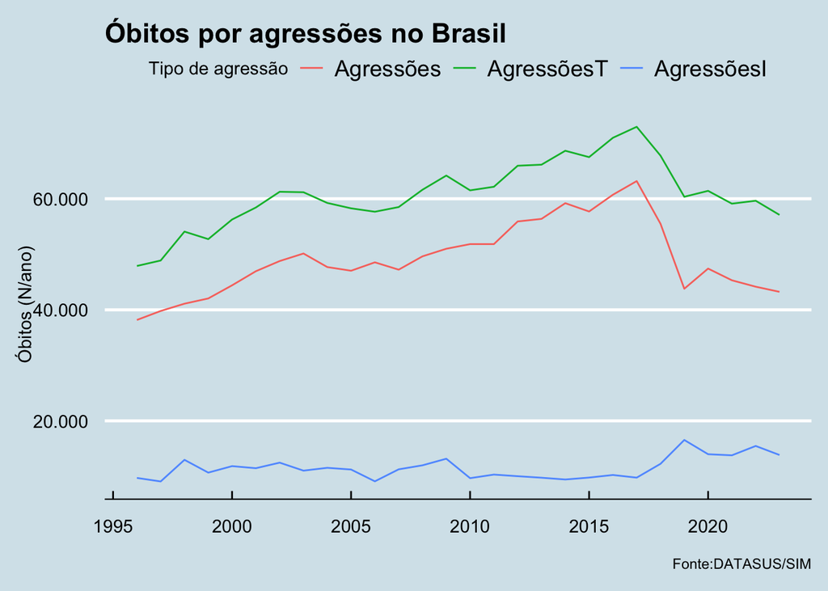

```r
agressoes.st %>%
  ggplot()+
  geom_line(aes(x=year, y=N, color=agressao))+
  labs(title = "Óbitos por agressões no Brasil",
       y = "Óbitos (N/ano)",
       x="",
       color="Tipo de agressão",
       caption = "Fonte:DATASUS/SIM")+
  scale_y_continuous(labels = scales::comma_format(big.mark = ".",
                                           decimal.mark = ","))+
  scale_x_continuous(breaks = seq(from =1995, to =2026,by=5))+
  theme_economist()
```

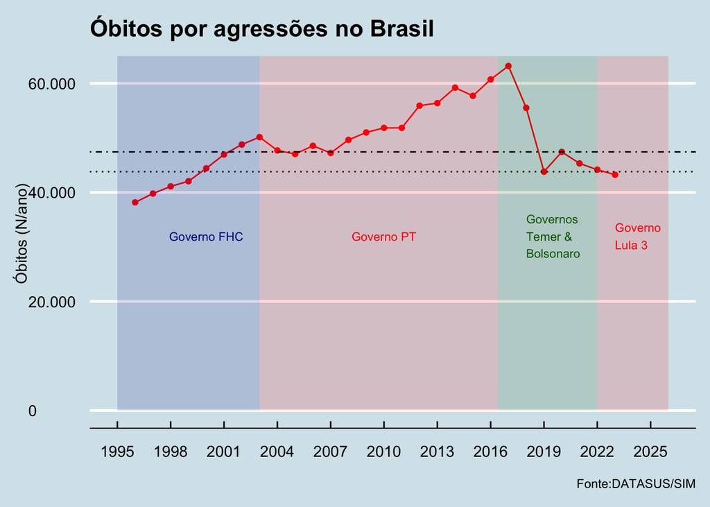

```r
agressoes.st[agressao=='Agressões'] %>%
  ggplot()+
  geom_point(aes(x = year, y = N),color = "red")+
  geom_line(aes(x = year, y = N),color = "red")+

  geom_hline(yintercept = agressoes.st[agressao=='Agressões' & year==2019,N],linetype=3,color="black")+
  geom_hline(yintercept = agressoes.st[agressao=='Agressões' & year==2020,N],linetype=4,color="black")+

  scale_y_continuous(labels = scales::comma_format(big.mark = ".",
                                           decimal.mark = ","))+
  scale_x_continuous(breaks = seq(from =1995, to = 2026, 3))+

  annotate(geom = "text", label="Governo FHC", x=2000, y=32000, color="dark blue",size=3)+
  geom_area(data = data.table(Ano=seq(from=1995, to=2003, by=.1),Obitos=65000),aes(x=Ano,y=Obitos),fill="dark blue",alpha=.15)+

  annotate(geom = "text", label="Governo PT", x=2010, y=32000, color="red",size=3)+
  geom_area(data = data.table(Ano=seq(from=2003, to=2016.417, by=.001),Obitos=65000),aes(x=Ano,y=Obitos),fill="red",alpha=.15)+

  annotate(geom = "text", label="Governos \nTemer &\nBolsonaro", x=2018, y=32000, color="dark green",hjust=0,size=3)+
  geom_area(data = data.table(Ano=seq(from=2016.417, to=2022, by=.001),Obitos=65000),aes(x=Ano,y=Obitos),fill="dark green",alpha=.15)+

  annotate(geom = "text", label="Governo \nLula 3", x=2023, y=32000, color="red",hjust=0,size=3)+
  geom_area(data = data.table(Ano=seq(from=2022, to=2026, by=.001),Obitos=65000),aes(x=Ano,y=Obitos),fill="red",alpha=.15)+

  theme_economist()+
  labs(title = "Óbitos por agressões no Brasil",
       y = "Óbitos (N/ano)",
       x="",
       caption = "Fonte:DATASUS/SIM")
```

# Codigos para Causas Externas

### Causas externas de morbidade e mortalidade (Capítulo XX - V01-Y98)

#### Acidentes (V01-X59)

- **V01-V99**: Acidentes de transporte
- **W00-W19**: Quedas
- **W20-W49**: Exposição a forças mecânicas inanimadas
- **W50-W64**: Exposição a forças mecânicas animadas
- **W65-W74**: Afogamento e submersão acidentais
- **W75-W84**: Outras ameaças à respiração
- **W85-W99**: Exposição a corrente elétrica, radiação e extremos de temperatura e pressão
- **X00-X09**: Exposição à fumaça, fogo e chamas
- **X10-X19**: Contato com calor e substâncias quentes
- **X20-X29**: Contato com animais e plantas venenosos
- **X30-X39**: Exposição a forças da natureza
- **X40-X49**: Envenenamento acidental e exposição a substâncias nocivas
- **X50-X57**: Sobrecarga física e outros efeitos ambientais
- **X58-X59**: Exposição a outros fatores especificados

#### Lesões autoprovocadas (X60-X84)

- **X60-X69**: Envenenamento autoprovocado
- **X70-X79**: Lesão autoprovocada por outros meios especificados
- **X80-X84**: Lesão autoprovocada por meios não especificados

#### Agressões (X85-Y09)

- **X85-X90**: Envenenamento por substância
- **X91-X98**: Uso de objeto contundente ou perfurante
- **X99-Y09**: Agressões por outros meios especificados

#### Eventos de intenção não determinada (Y10-Y34)

- **Y10-Y19**: Envenenamento
- **Y20-Y29**: Uso de objeto contundente ou perfurante
- **Y30-Y34**: Outros meios

#### Complicações de cuidados médicos e cirúrgicos (Y40-Y84)

- **Y40-Y59**: Complicações de drogas e medicamentos
- **Y60-Y84**: Complicações de procedimentos médicos e cirúrgicos

#### Outros fatores externos (Y85-Y98)

- **Y85-Y89**: Sequelas de causas externas
- **Y90-Y98**: Outros fatores e causas externos

### Códigos específicos para agressões

- **X85**: Agressão por envenenamento com drogas, medicamentos e substâncias biológicas
- **X86**: Agressão por envenenamento com outras substâncias químicas e substâncias nocivas
- **X87**: Agressão por pesticidas
- **X88**: Agressão por gases e vapores
- **X89**: Agressão por substâncias químicas corrosivas
- **X90**: Agressão por substâncias químicas não especificadas
- **X91**: Agressão por suspensão (estrangulamento)
- **X92**: Agressão por afogamento e submersão
- **X93**: Agressão por disparo de arma de fogo (pistola, revólver, rifle)
- **X94**: Agressão por disparo de arma de fogo (espingarda)
- **X95**: Agressão por disparo de outras armas de fogo e não especificadas
- **X96**: Agressão por explosivos
- **X97**: Agressão por fumo, fogo e chamas
- **X98**: Agressão por objeto cortante
- **X99**: Agressão por objeto contundente
- **Y00**: Agressão por força corporal (socos, pontapés)
- **Y01**: Agressão por projeção de objeto arremessado
- **Y02**: Agressão por empurrão contra objeto (queda)
- **Y03**: Agressão por projeção de pessoa de lugar elevado
- **Y04**: Agressão por força física não especificada
- **Y05**: Agressão sexual por força física
- **Y06**: Negligência e abandono
- **Y07**: Outros maus-tratos
- **Y08**: Agressão por meio não especificado
- **Y09**: Agressão por meio não especificado (genérico)